# The logistic model

Peter Ralph

24 November 2020 – Advanced Biological Statistics

# The logistic model, a.k.a. “logistic regression”

## Motivation

There’s a good bit more information available about the baseball players.

```r
batplus <- read.csv("data/BattingAveragePlus.csv",
                    header=TRUE, stringsAsFactors=TRUE)
head(batplus)
```

```
##             Player     PriPos Hits AtBats PlayerNumber PriPosNumber  playerID weight height bats birthYear      debut  finalGame
## 1 Aaron Cunningham Left Field   17     97          198            7 cunniaa01    215     71    R      1986 2008-08-31 2012-07-24
## 2     Aaron Harang    Pitcher    4     56          360            1 haranaa01    260     79    R      1978 2002-05-25 2015-10-03
## 3       Aaron Hill   2nd Base  184    609          394            4  hillaa01    200     71    R      1982 2005-05-20 2016-10-01
## 4     Aaron Laffey    Pitcher    0      1          482            1 laffeaa01    190     71    L      1985 2007-08-04 2015-07-31
## 5       Aaron Loup    Pitcher    0      1          522            1  loupaa01    210     71    L      1987 2012-07-14 2016-09-30
## 6        Adam Dunn   1st Base  110    539          242            3  dunnad01    285     78    L      1979 2001-07-20 2014-09-28
```

Is batting average predicted by weight and height?

1. Each player has their own batting avg, $\theta_i$.
2. Batting averages tend to be different for different positions.
3. After accounting for position ($p_i$), $\theta$ varies with height ($h_i$) and/or weight ($w_i$).

*Motivation:*

```r
lm( Hits/AtBats ~ PriPos + weight + height, data=batplus )
```

# Relating values to probabilities

## The logistic function

$$\begin{aligned}
f(x) = \frac{1}{1 + e^{-x}} .
\end{aligned}$$

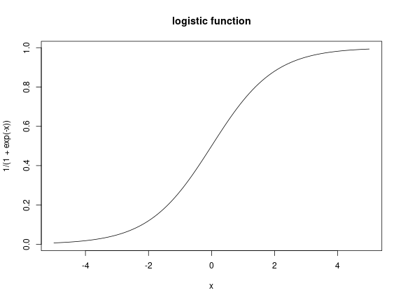

## … is the inverse of the logit function

$$\begin{aligned}
f^{-1}(x) = \log\left(\frac{x}{1-x}\right) .
\end{aligned}$$

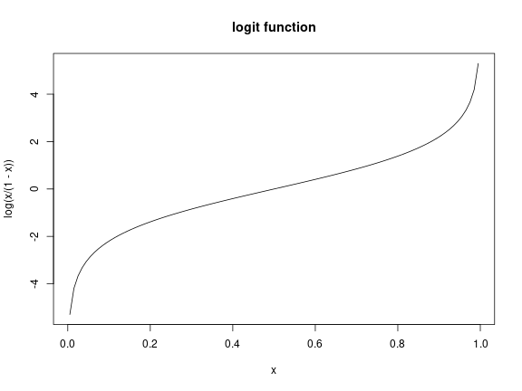

# Back to Stan

1. Each player has their own batting avg, $\theta_i$.
2. Batting averages tend to be different for different positions.
3. After accounting for position ($p_i$), $\theta$ varies with height ($h_i$) and/or weight ($w_i$).

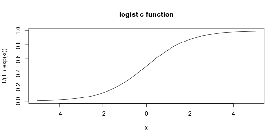

$$\begin{aligned}
Z_i &\sim \Binom(N_i, \theta_i) \\
\theta_i &\sim \Beta(\mu_i \kappa_{p_i}, (1-\mu_i) \kappa_{p_i}) \\
\mu_i &= \logistic(\gamma_{p_i} + \alpha_h h_i + \alpha_w w_i) \\
\kappa_p &\sim \Gam(0.1, 0.1) \\
\gamma_{p} &\sim \Normal(0, 5) \\
\alpha_h &\sim \Normal(0, 5) \\
\alpha_w &\sim \Normal(0, 5)
\end{aligned}$$

## Questions:

1. How much do we expect $\gamma$ to differ for pitchers versus catchers?
2. What would a value of $\alpha_h = 1$ mean?
3. What would be a range of plausible values for $\alpha_h$ and $\alpha_w$?
4. Are the priors sensible?

*Note:* we’ll **center and scale** weight and height, so that $h$ and $w$ will be in units of *standard deviations from the mean*.

## Stan

```r
logistic_model <- "
data {
    int N;   // number of players
    int hits[N];
    int at_bats[N];
    int npos; // number of positions
    int position[N];
    vector[N] height;
    vector[N] weight;
}
parameters {
    real<lower=0, upper=1> theta[N];
    vector[npos] gamma;
    real alpha_w;
    real alpha_h;
    vector<lower=0>[npos] kappa;
}
model {
    vector[N] mu;
    mu = inv_logit(gamma[position] + alpha_h * height + alpha_w * weight);
    theta ~ beta(mu .* kappa[position], (1-mu) .* kappa[position]);
    hits ~ binomial(at_bats, theta);
    kappa ~ gamma(0.1, 0.1);
    gamma ~ normal(0, 5);
    alpha_h ~ normal(0, 5);
    alpha_w ~ normal(0, 5);
} "
```

$$\begin{aligned}
Z_i &\sim \Binom(N_i, \theta_i) \\
\theta_i &\sim \Beta(\mu_i \kappa_{p_i}, (1-\mu_i) \kappa_{p_i}) \\
\mu_i &= \logistic(\gamma_{p_i} + \alpha_h h_i + \alpha_w w_i) \\
\kappa_p &\sim \Gam(0.1, 0.1) \\
\gamma_{p} &\sim \Normal(0, 5) \\
\alpha_h &\sim \Normal(0, 5) \\
\alpha_w &\sim \Normal(0, 5)
\end{aligned}$$

## New features

```r
logistic_model <- "
data {
    int N;   // number of players
    int hits[N];
    int at_bats[N];
    int npos; // number of positions
    int position[N];
    vector[N] height;
    vector[N] weight;
}
parameters {
    real<lower=0, upper=1> theta[N];
    vector[npos] gamma;
    real alpha_w;
    real alpha_h;
    vector<lower=0>[npos] kappa;
}
model {
    vector[N] mu;
    mu = inv_logit(gamma[position] + alpha_h * height + alpha_w * weight);
    theta ~ beta(mu .* kappa[position], (1-mu) .* kappa[position]);
    hits ~ binomial(at_bats, theta);
    kappa ~ gamma(0.1, 0.1);
    gamma ~ normal(0, 5);
    alpha_h ~ normal(0, 5);
    alpha_w ~ normal(0, 5);
} "
```

1. `vector[N] height;` instead of `real height[N];`: to allow `alpha_h * height`.
2. `gamma[position]` for vectorized indexing
3. `x .* y` for component-wise multiplication

```
data {
    int N;   // number of players
    int hits[N];
    int at_bats[N];
    int npos; // number of positions
    int position[N];
    vector[N] height;
    vector[N] weight;
}
parameters {
    real<lower=0, upper=1> theta[N];
    vector[npos] gamma;
    real alpha_w;
    real alpha_h;
    vector<lower=0>[npos] kappa;
}
model {
    vector[N] mu;
    mu = inv_logit(gamma[position] + alpha_h * height + alpha_w * weight);
    theta ~ beta(mu .* kappa[position], (1-mu) .* kappa[position]);
    hits ~ binomial(at_bats, theta);
    kappa ~ gamma(0.1, 0.1);
    gamma ~ normal(0, 5);
    alpha_h ~ normal(0, 5);
    alpha_w ~ normal(0, 5);
}
```

```r
scaled_height <- (batplus$height - mean(batplus$height))/sd(batplus$height)
scaled_weight <- (batplus$weight - mean(batplus$weight))/sd(batplus$weight)
system.time(logistic_fit <- stan(model_code=logistic_model, chains=3, iter=1000,
                               control=list(adapt_delta=0.9, max_treedepth=12),
                               data=list(N=nrow(batplus),
                                      hits=batplus$Hits,
                                      at_bats=batplus$AtBats,
                                      npos=nlevels(batplus$PriPos),
                                      position=as.numeric(batplus$PriPos),
                                      height=scaled_height,
                                      weight=scaled_weight) ))
```

```
##    user  system elapsed
## 236.737   3.067 136.295
```

```r
logistic_summary <- rstan::summary(logistic_fit)$summary
print(logistic_summary)
```

```
##                     mean      se_mean          sd          2.5%           25%           50%           75%         97.5%     n_eff      Rhat
## theta[1]    2.148156e-01 0.0004895183  0.02991918  1.579063e-01  1.941524e-01  2.138817e-01  2.343610e-01  2.767836e-01 3735.6098 0.9990097
## theta[2]    1.003653e-01 0.0005782312  0.02849696  5.306210e-02  7.991658e-02  9.857809e-02  1.170653e-01  1.636435e-01 2428.8136 0.9988730
## theta[3]    2.944825e-01 0.0002728778  0.01673599  2.616927e-01  2.832199e-01  2.945440e-01  3.054410e-01  3.283094e-01 3761.5452 1.0003648
## theta[4]    1.255611e-01 0.0007781808  0.04611151  5.094841e-02  9.145170e-02  1.192610e-01  1.548317e-01  2.272874e-01 3511.2167 0.9990836
## theta[5]    1.278928e-01 0.0007827714  0.04515064  5.249705e-02  9.585853e-02  1.231579e-01  1.536206e-01  2.305225e-01 3327.0384 0.9982984
## theta[6]    2.135464e-01 0.0002651778  0.01501348  1.841361e-01  2.030753e-01  2.135709e-01  2.241366e-01  2.430412e-01 3205.4433 0.9989146
## theta[7]    2.836905e-01 0.0002475901  0.01666656  2.513674e-01  2.722146e-01  2.834145e-01  2.950135e-01  3.168391e-01 4531.3244 0.9985201
## theta[8]    2.592205e-01 0.0004359554  0.02634874  2.088928e-01  2.409917e-01  2.582475e-01  2.766390e-01  3.104745e-01 3652.8815 0.9982158
## theta[9]    2.679523e-01 0.0003074171  0.01801718  2.334174e-01  2.558237e-01  2.673880e-01  2.796924e-01  3.026122e-01 3434.9272 0.9987408
## theta[10]   2.538053e-01 0.0003556777  0.02010518  2.157586e-01  2.396471e-01  2.532459e-01  2.665435e-01  2.936045e-01 3195.2323 0.9994622
## theta[11]   2.302025e-01 0.0006947231  0.03975017  1.545434e-01  2.031180e-01  2.285270e-01  2.560426e-01  3.094085e-01 3273.8179 0.9983134
## theta[12]   1.263563e-01 0.0006148987  0.04043674  6.195028e-02  9.700767e-02  1.233391e-01  1.500432e-01  2.131228e-01 4324.5922 0.9982843
## theta[13]   2.353829e-01 0.0004840317  0.03048394  1.790708e-01  2.145157e-01  2.330910e-01  2.546901e-01  2.985072e-01 3966.3822 0.9984840
## theta[14]   1.249369e-01 0.0004947384  0.02893057  7.574865e-02  1.039302e-01  1.229870e-01  1.435586e-01  1.850465e-01 3419.5018 0.9982500
## theta[15]   2.541252e-01 0.0004750122  0.03044023  1.961427e-01  2.335936e-01  2.523259e-01  2.742607e-01  3.174373e-01 4106.6382 0.9983306
## theta[16]   3.128254e-01 0.0002522363  0.01647901  2.820343e-01  3.013209e-01  3.127038e-01  3.239244e-01  3.459915e-01 4268.2222 0.9995049
## theta[17]   2.246161e-01 0.0004817428  0.03253286  1.662249e-01  2.029647e-01  2.233196e-01  2.452648e-01  2.921827e-01 4560.5172 0.9983374
## theta[18]   2.915854e-01 0.0002702474  0.01682222  2.596274e-01  2.801131e-01  2.917343e-01  3.032590e-01  3.248219e-01 3874.7503 0.9990705
## theta[19]   2.464460e-01 0.0005610891  0.03669900  1.777676e-01  2.213166e-01  2.461448e-01  2.704123e-01  3.225320e-01 4278.0403 0.9988460
## theta[20]   2.804242e-01 0.0002543573  0.01755643  2.459561e-01  2.685267e-01  2.797559e-01  2.920458e-01  3.157570e-01 4764.1369 0.9988924
## theta[21]   2.536304e-01 0.0002634724  0.01722258  2.207695e-01  2.421085e-01  2.535127e-01  2.651750e-01  2.886077e-01 4272.9339 0.9992759
## theta[22]   2.448342e-01 0.0005812362  0.04011851  1.718933e-01  2.160986e-01  2.428409e-01  2.713018e-01  3.296463e-01 4764.1369 0.9982871
## theta[23]   2.864708e-01 0.0002734237  0.01706008  2.545197e-01  2.748472e-01  2.863169e-01  2.979580e-01  3.203381e-01 3893.0472 1.0002233
## theta[24]   2.774947e-01 0.0002677792  0.01848285  2.412801e-01  2.642910e-01  2.773307e-01  2.898415e-01  3.141294e-01 4764.1369 0.9988126
## theta[25]   2.412510e-01 0.0002783916  0.01921535  2.047796e-01  2.286505e-01  2.407363e-01  2.528449e-01  2.806900e-01 4764.1369 0.9984342
## theta[26]   2.338728e-01 0.0006523662  0.03794735  1.618144e-01  2.079668e-01  2.324794e-01  2.585896e-01  3.096306e-01 3383.6084 0.9986281
## theta[27]   2.880101e-01 0.0002742402  0.01681823  2.565334e-01  2.765935e-01  2.877804e-01  2.992742e-01  3.220582e-01 3760.9587 0.9997072
## theta[28]   1.227010e-01 0.0007901987  0.04380291  5.044460e-02  9.098764e-02  1.190169e-01  1.490381e-01  2.266273e-01 3072.7933 0.9983970
## theta[29]   2.383414e-01 0.0005263577  0.02931153  1.830017e-01  2.188387e-01  2.385015e-01  2.567642e-01  2.973502e-01 3101.0947 0.9992676
## theta[30]   2.388247e-01 0.0003362131  0.01997761  2.019232e-01  2.249391e-01  2.383684e-01  2.524366e-01  2.781579e-01 3530.6769 0.9990945
## theta[31]   2.961167e-01 0.0002564842  0.01770324  2.610573e-01  2.839316e-01  2.959745e-01  3.077493e-01  3.310704e-01 4764.1369 0.9983916
## theta[32]   2.697734e-01 0.0002909197  0.01858983  2.334089e-01  2.570431e-01  2.697690e-01  2.818372e-01  3.081321e-01 4083.2347 0.9993904
## theta[33]   1.456823e-01 0.0006856722  0.03910784  7.712402e-02  1.180785e-01  1.433942e-01  1.715518e-01  2.310906e-01 3253.0789 0.9993149
## theta[34]   2.618153e-01 0.0002577640  0.01613493  2.313864e-01  2.504122e-01  2.617284e-01  2.729697e-01  2.929005e-01 3918.2258 0.9985134
## theta[35]   2.418529e-01 0.0003196474  0.02206293  2.003181e-01  2.271608e-01  2.416241e-01  2.565061e-01  2.843876e-01 4764.1369 0.9986727
## theta[36]   2.426113e-01 0.0003009631  0.02077329  2.041988e-01  2.283954e-01  2.422236e-01  2.568515e-01  2.838260e-01 4764.1369 0.9982894
## theta[37]   1.417141e-01 0.0007040871  0.04780257  6.129505e-02  1.076241e-01  1.374430e-01  1.700717e-01  2.499797e-01 4609.4570 0.9990695
## theta[38]   2.590063e-01 0.0002394590  0.01652812  2.289967e-01  2.476398e-01  2.587624e-01  2.696099e-01  2.922782e-01 4764.1369 0.9990901
## theta[39]   1.231167e-01 0.0009508699  0.04429075  5.030158e-02  9.164862e-02  1.185251e-01  1.500981e-01  2.199042e-01 2169.6211 0.9997138
```

[output cut: 853 more lines]

```
## gamma[7]   -1.910327e+00 0.0024500712  0.05708249 -2.020372e+00 -1.947511e+00 -1.911070e+00 -1.870077e+00 -1.802286e+00  542.8108 1.0035191
## gamma[8]   -1.054927e+00 0.0009197498  0.03865135 -1.133037e+00 -1.080092e+00 -1.054404e+00 -1.029045e+00 -9.800656e-01 1765.9970 0.9986652
## gamma[9]   -1.104083e+00 0.0009982007  0.04181421 -1.189718e+00 -1.131950e+00 -1.102983e+00 -1.076656e+00 -1.025579e+00 1754.7373 0.9989844
## alpha_w     2.049676e-02 0.0004108001  0.01745399 -1.340492e-02  9.257595e-03  2.071060e-02  3.258175e-02  5.315404e-02 1805.2128 1.0006108
## alpha_h    -9.700853e-03 0.0004146935  0.01679267 -4.196653e-02 -2.112763e-02 -9.784652e-03  1.439943e-03  2.429819e-02 1639.7783 1.0021566
## kappa[1]    1.073369e+02 0.6112569762 23.16902526  6.971627e+01  9.115426e+01  1.047902e+02  1.208600e+02  1.593637e+02 1436.7059 1.0016171
## kappa[2]    1.043715e+02 0.6406791673 24.26721462  6.306153e+01  8.655679e+01  1.019539e+02  1.192425e+02  1.586246e+02 1434.6919 1.0038683
## kappa[3]    9.716261e+01 0.5734302455 20.93812699  6.295223e+01  8.229606e+01  9.498135e+01  1.097060e+02  1.434381e+02 1333.2588 1.0011472
## kappa[4]    9.099094e+01 0.6754700335 19.92277718  5.666480e+01  7.793669e+01  8.885483e+01  1.025654e+02  1.367810e+02  869.9366 1.0050622
## kappa[5]    9.310357e+01 0.6122438986 21.07456643  5.709713e+01  7.746350e+01  9.135139e+01  1.059954e+02  1.378341e+02 1184.8636 0.9994984
## kappa[6]    1.057961e+02 0.7154399239 22.64204151  6.706051e+01  8.898902e+01  1.042585e+02  1.197122e+02  1.558970e+02 1001.5781 0.9995559
## kappa[7]    5.549164e+01 1.2936330975 14.24024358  3.363938e+01  4.530643e+01  5.369662e+01  6.343142e+01  9.093293e+01  121.1749 1.0079337
## kappa[8]    1.098204e+02 0.6514618767 25.19801855  6.719365e+01  9.124733e+01  1.080589e+02  1.255475e+02  1.615100e+02 1496.0798 1.0001329
## kappa[9]    8.919671e+01 0.5928389060 21.64802366  5.143198e+01  7.405744e+01  8.721235e+01  1.029605e+02  1.355706e+02 1333.4082 0.9988656
## lp__       -8.739899e+04 3.6528452961 40.32669990 -8.747462e+04 -8.742666e+04 -8.740072e+04 -8.737193e+04 -8.731784e+04  121.8773 1.0076574
```

## Pitchers still don’t bat well

```
## ci_level: 0.8 (80% intervals)
```

```
## outer_level: 0.95 (95% intervals)
```

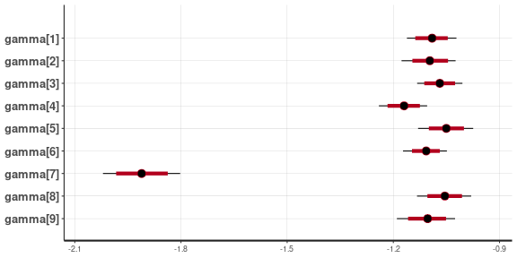

```r
stan_plot(logistic_fit, pars="gamma")
```

Recall the *mean* of $\theta_i$ is
$$\begin{aligned}
\mu_i = \frac{1}{1 + \exp(-\gamma_{p_i} - \alpha_h h_i - \alpha_w w_i)} .
\end{aligned}$$

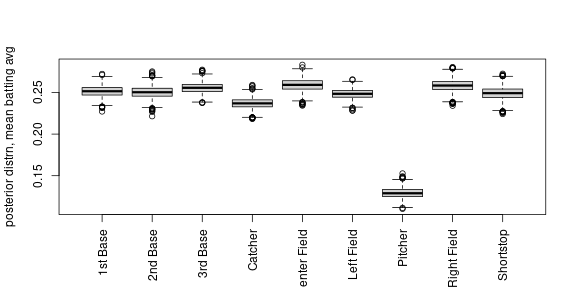

```r
gamma_samples <- rstan::extract(logistic_fit)$gamma
colnames(gamma_samples) <- levels(batplus$PriPos)
mu_samples <- 1/(1+exp(-gamma_samples))
boxplot(mu_samples, ylab="posterior distrn, mean batting avg", las=3)
```

## No effect of height or weight

```
## ci_level: 0.8 (80% intervals)
```

```
## outer_level: 0.95 (95% intervals)
```

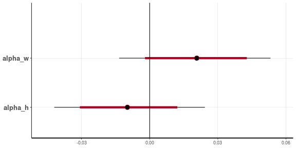

```r
stan_plot(logistic_fit, pars=c("alpha_w", "alpha_h")) + geom_vline(xintercept=0)
```

## Same $\theta$ as before?

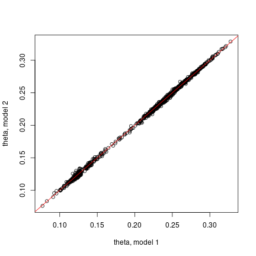

```r
new_post_theta <- colMeans(rstan::extract(logistic_fit)$theta)
old_post_theta <- batting$post_mean[match(batplus$Player, batting$Player)]
plot(old_post_theta, new_post_theta, xlab="theta, model 1", ylab="theta, model 2")
abline(0,1, col='red')
```

## Conclusions

1. It doesn’t look like batting average varies substantially with height or weight, if at all.
2. Changing the model from a Beta prior on class means to a logistic transform of a Normal prior did not substantially affect the results.